# Lab #4 Normalization and Bioconductor

Xulin Ge

Jul 08 2023

We will be working with a few data sets, each run on a different platform.

The first data set is an R object generated from a 2-channel cDNA array that is called `swirl`.

This data set is an experiment that was run on a zebrafish to study the early development. “swirl is a point mutant in the BMP2 gene that affects the dorsal/ventral body axis.” The objective of the experiment was to evaluate the transcript differences between wildtype zebrafish and those with this mutation.

Because `swirl` is an R object, so the format and structure of this binary file has to be accessed through various R functions. If you type “swirl”, you will immediately see that there are attributes that make up this file (e.g. @maInfo) beyond the typical channel information. Included is metadata information that makes up the experimental parameters, in addition to the raw intensity data.

The second 2 data sets are raw intensity files – one from an Agilent platform and the other from an Affymetrix platform.

These are not R objects, rather the Agilent files are raw text files generated from the Agilent software and the Affymetrix files are raw binary files generated from the Affymetrix software.

Since both R objects and raw data files are typically what an analyst is given when asked to analyze an experiment, this lab will give you experience processing raw intensity files and normalizing them appropriately. This is typically the first step in conducting any microarray analysis, so it is important to make sure that the data is normalized appropriately before beginning any subsequent steps

```r
# installing/loading the package:
if(!require(fpc)) {
  install.packages("fpc");
  require(fpc)
}

list.of.packages <- c("marray","affy","limma","affydata", "affyPLM", "fpc")
new.packages <- list.of.packages[!(list.of.packages %in% installed.packages()[,"Package"])]
if(length(new.packages)>0) BiocManager::install(new.packages)
```

```r
# Set the directory
(WD <- getwd())
if (!is.null(WD)) setwd(WD)
```

# `swirl` data set

Load the marray library and the `swirl` data set

```r
# Load the packages and dataset
library(marray)
data(swirl)
dim(swirl)
```

```
## [1] 8448    4
```

### Non-normalized data

Plot an MvA plot of array 3 without any stratified lines

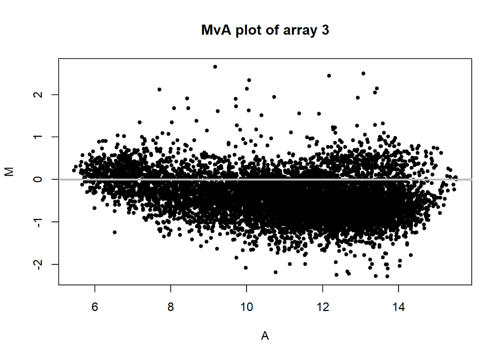

```r
maPlot(swirl[,3], lines.func=NULL, legend.func=NULL,
    main='MvA plot of array 3')
```

### Global median location normalization

Normalize array 3 by global median location normalization

```r
# Post-normalization using global median location normalization
# median, for global median location normalization
# loess, for global intensity location normalization
mnorm_median <- maNorm(swirl[,3], norm="median")
```

Plot an MvA plot of the normalized array without the stratified lines or legend

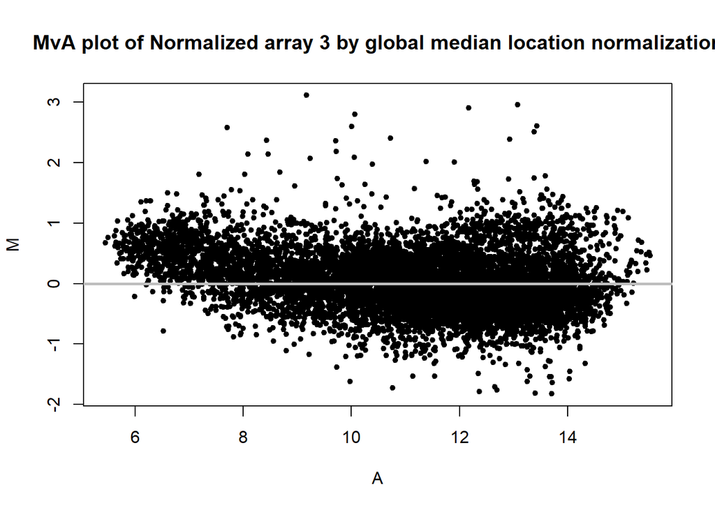

```r
maPlot(mnorm_median, lines.func=NULL, legend.func=NULL,
    main='MvA plot of Normalized array 3 by global median location normalization')
```

If we compare normalized vs. non-normalized data, we can see that normalized data points moves up vertically along y axis. This indicates a simple constant has been added to each value

### Loess global intensity normalization

We will repeat steps above except replacing `median` to `loess`

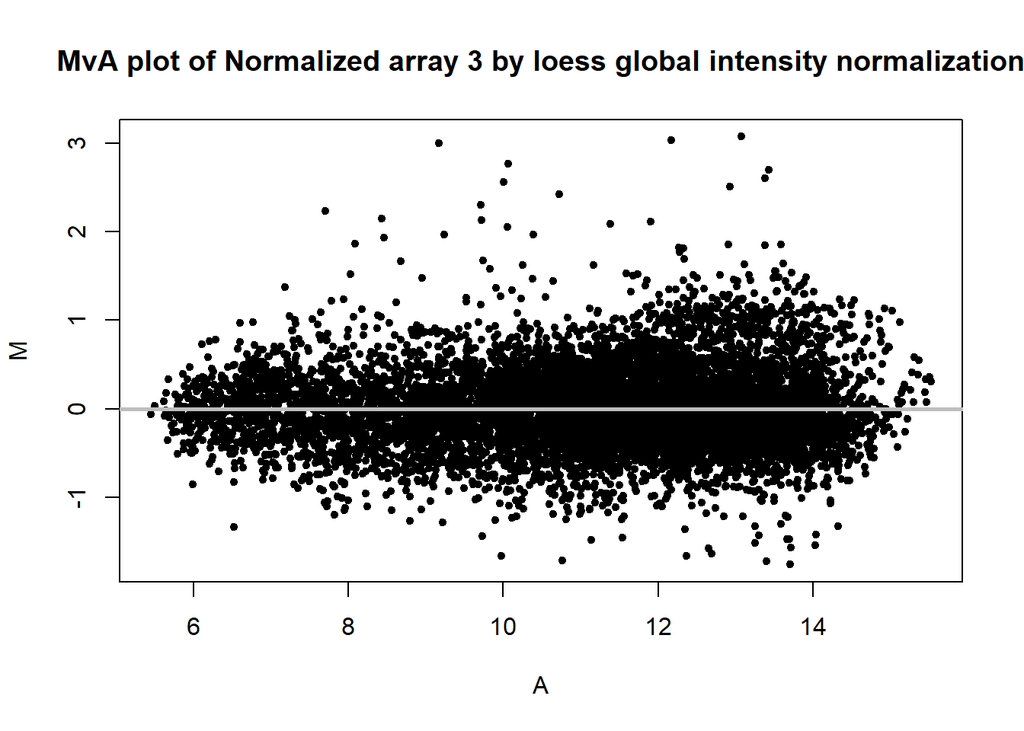

```r
mnorm_loess <- maNorm(swirl[,3], norm="loess")
maPlot(mnorm_loess, lines.func=NULL, legend.func=NULL,
    main='MvA plot of Normalized array 3 by loess global intensity normalization')
```

Loess global intensity normalization looks to be better for `swirl` array 3

Because the data points seem to be less “curved” and more “even”, which means the normalization reduces differences between replicate samples.

# Raw GenePix files

Next, we would like to read in raw GenePix files for 2 cDNA arrays that represent 2 patient samples

```r
# using the read.GenePix() function
a.cdna <- read.GenePix(path="data\\", name.Gf = "F532 Median",name.Gb ="B532 Median", name.Rf = "F635 Median", name.Rb = "B635 Median",name.W ="Flags")
```

```
## Reading ...  data\/patient1.gpr
## Reading ...  data\/patient2.gpr
```

```r
dim(a.cdna)
```

```
## [1] 19200     2
```

Note that the `a.cdna` object is analogous to the swirl metadata object

### Normalize both arrays and provide MvA plots for each array normalized by the following 3 methods:

no normalization

print-tip loess normalization

scale print-tip normalization using the MAD

Hint: use the `par(mfrow=c(3,1))` function to put the 3 plots for a single patient array on the same page

```r
# no normalization
patient1 <- a.cdna[,1]
patient2 <- a.cdna[,2]
# print-tip loess normalization
patient1.print_tip <- maNorm(patient1, norm="printTipLoess")
patient2.print_tip <- maNorm(patient2, norm="printTipLoess")
# scale print-tip normalization using the MAD
patient1.scale_print_tip <- maNorm(patient1, norm="scalePrintTipMAD")
patient2.scale_print_tip <- maNorm(patient2, norm="scalePrintTipMAD")
```

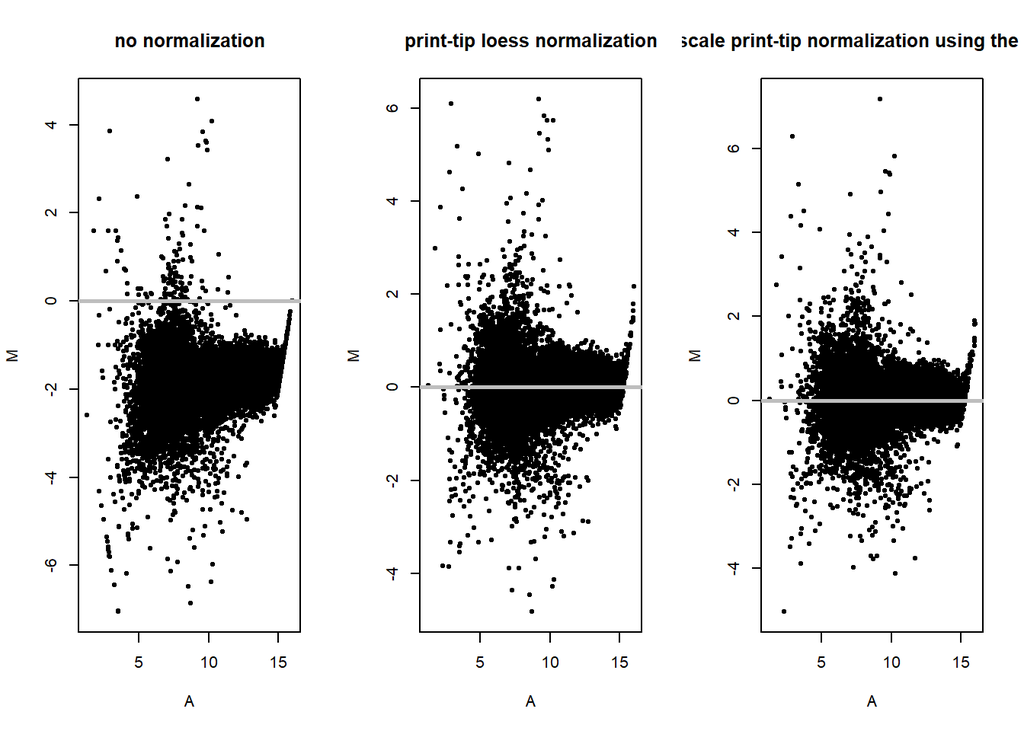

```r
# MvA plot of patient array 1
par(mfrow=c(1,3))
maPlot(patient1, lines.func=NULL, legend.func=NULL,
    main='no normalization')
maPlot(patient1.print_tip, lines.func=NULL, legend.func=NULL,
    main='print-tip loess normalization')
maPlot(patient1.scale_print_tip, lines.func=NULL, legend.func=NULL,
    main='scale print-tip normalization using the MAD')
mtext("MvA plot of patient array 1", side=1, line=-40,  outer=FALSE)
```

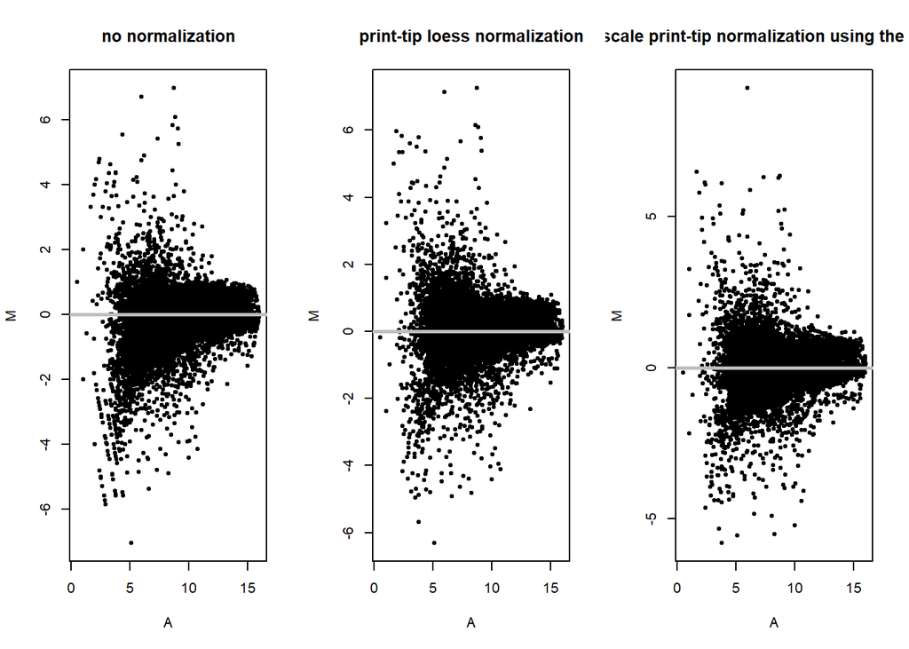

```r
# MvA plot of patient array 2
par(mfrow=c(1,3))
maPlot(patient2, lines.func=NULL, legend.func=NULL,
    main='no normalization')
maPlot(patient2.print_tip, lines.func=NULL, legend.func=NULL,
    main='print-tip loess normalization')
maPlot(patient2.scale_print_tip, lines.func=NULL, legend.func=NULL,
    main='scale print-tip normalization using the MAD')
mtext("MvA plot of patient array 2", side=1, line=-40,  outer=TRUE)
```

### Create a data matrix that can be written out to a file

Each patient array contains 19,200 rows and 2 columns

Using the functions `maM()`, `maGnames()`, and `maLabels()`.

Get the probe IDs, and assign the probe IDs to the row names

```r
# create the data matrix for the 2 normalized metadata objects
mat_print_tip <- data.frame(maM(patient1.print_tip), maM(patient2.print_tip))
mat_scale_print_tip <- data.frame(maM(patient1.scale_print_tip), maM(patient2.scale_print_tip))
# get the probe IDs
probeIDs <- maLabels(maGnames(a.cdna))
anyDuplicated(probeIDs)
```

```
## [1] 4
```

```r
# There're lots of duplicated probe IDs in the original data,
# so use make.names(.., unique = TRUE)
probeIDs <- make.names(probeIDs, unique = TRUE)
anyDuplicated(probeIDs)
```

```
## [1] 0
```

```r
# assign the probe IDs to the row names
rownames(mat_print_tip) <- probeIDs
rownames(mat_scale_print_tip) <- probeIDs

knitr::kable(head(mat_print_tip), caption="print-tip loess normalized data")
```

print-tip loess normalized data

|  | data..patient1.gpr | data..patient2.gpr |
| --- | --- | --- |
| X36894 | -0.0331101 | 0.1505862 |
| N.A | 0.1304948 | 0.1713035 |
| X5548382 | 0.5243589 | 0.3575525 |
| N.A.1 | -0.7808399 | -1.5229202 |
| X29305 | -0.4945091 | -0.6409908 |
| X28821 | -0.8363964 | -0.7880698 |

```r
knitr::kable(head(mat_scale_print_tip), caption="scale print-tip normalized data")
```

scale print-tip normalized data

|  | data..patient1.gpr | data..patient2.gpr |
| --- | --- | --- |
| X36894 | -0.0426144 | 0.1453677 |
| N.A | 0.1679531 | 0.1653669 |
| X5548382 | 0.6748757 | 0.3451614 |
| N.A.1 | -1.0049792 | -1.4701431 |
| X29305 | -0.6364574 | -0.6187771 |
| X28821 | -1.0764832 | -0.7607591 |

# Raw Affymetrix .CEL files

Next, we would like to read in 3 raw Affymetrix .CEL files and normalize them with 2 different algorithms. These 3 arrays represent 3 normal healthy subjects that should have similar expression profiles

```r
# Load the following libraries: affy, limma, affydata, affyPLM, and fpc
library(affy)
library(limma)
library(affydata)
library(affyPLM)
library(fpc)
```

### Read 3 `.CEL` files into R

```r
# using the read.ReadAffy() function
fns <- sort(list.celfiles(path="data\\", full.names=TRUE))
data.affy <- ReadAffy(filenames=fns, phenoData=NULL)
data.affy
```

```
## AffyBatch object
## size of arrays=1164x1164 features (19 kb)
## cdf=HG-U133_Plus_2 (54675 affyids)
## number of samples=3
## number of genes=54675
## annotation=hgu133plus2
## notes=
```

# RMA and MAS normalization

Use the function `expresso()` and `exprs()` to create the normalized data matrices with 54,675 rows and 3 columns for the 2 different normalization algorithms

Be sure to use `normalize.method="quantiles"`, `summary.method="medianpolish"`, and for RMA: `pmcorrect.method="pmonly"` MAS: `pmcorrect.method="mas”`

```r
# This step costs a few minutes
start_time <- Sys.time()

# RMA
data.affy.RMA <- expresso(data.affy,
    bgcorrect.method="rma", normalize.method="quantiles",
    summary.method="medianpolish", pmcorrect.method="pmonly")
```

```
## background correction: rma
## normalization: quantiles
## PM/MM correction : pmonly
## expression values: medianpolish
## background correcting...done.
## normalizing...done.
## 54675 ids to be processed
## |                    |
## |####################|
```

```r
# MAS
data.affy.MAS <- expresso(data.affy,
    bgcorrect.method="rma", normalize.method="quantiles",
    summary.method="medianpolish", pmcorrect.method="mas")
```

```
## background correction: rma
## normalization: quantiles
## PM/MM correction : mas
## expression values: medianpolish
## background correcting...done.
## normalizing...done.
## 54675 ids to be processed
## |                    |
## |####################|
```

```r
end_time <- Sys.time()
end_time - start_time
```

```
## Time difference of 5.442354 mins
```

Create the normalized data matrices with 54,675 rows and 3 columns

```r
mat_RMA <- exprs(data.affy.RMA)
dim(mat_RMA)
```

```
## [1] 54675     3
```

```r
mat_MAS <- exprs(data.affy.MAS)
dim(mat_MAS)
```

```
## [1] 54675     3
```

# Calculate the correlation between the 3 arrays for both normalized data matrices

Use the `cor()` function.

Since these 3 subjects are all healthy normal individuals, we would expect to see somewhat good correlation structure between them all when looking across all genes on the array.

```r
cor_RMA <- cor(mat_RMA)
knitr::kable(cor_RMA, caption="RMA normalized data matrices")
```

RMA normalized data matrices

[output not shown]

```r
cor_MAS <- cor(mat_MAS)
knitr::kable(cor_MAS, caption="MAS normalized data matrices")
```

MAS normalized data matrices

[output not shown]

As the correction matrices show, take normal2.CEL as an example,

RMA gives: 0.9766785 1.0000000 0.9913585

MAS gives: 0.9563402 1.0000000 0.9871987

Thus, RMA normalization algorithm has a higher overall correlation structure for these 3 arrays

We can also look at their means

```r
apply(cor_RMA,2,mean)
```

```
## data\\normal1.CEL data\\normal2.CEL data\\normal3.CEL
##         0.9841721         0.9893457         0.9890654
```

```r
apply(cor_MAS,2,mean)
```

```
## data\\normal1.CEL data\\normal2.CEL data\\normal3.CEL
##         0.9708222         0.9811797         0.9811084
```

On average, RMA normalized data also has a higher correlation for these 3 arrays